# Homework 1

# MODEL 2 (CPI)

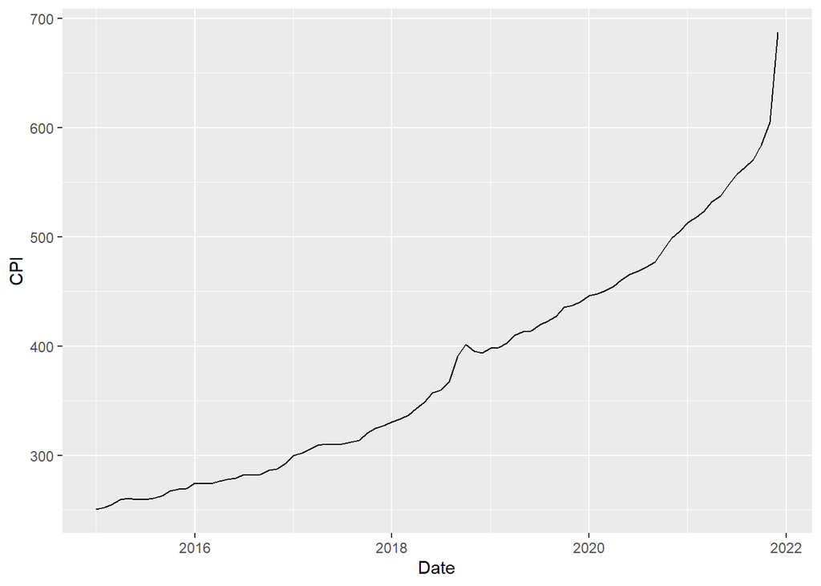

```r
ggplot(all_data_table ,aes(x=Date,y=CPI, group=1)) + geom_line()
```

I have decided to use dollar/tl exchange rate to predict CPI. The graph below is the scatter plot and regression line for dollar/tl exchange rate and CPI.

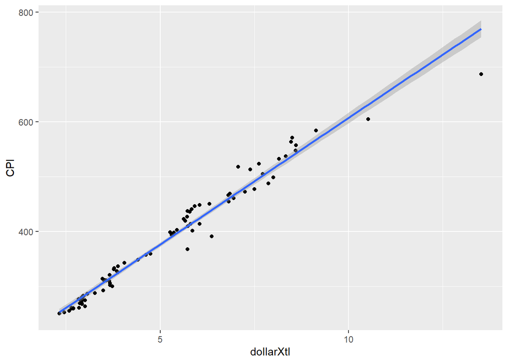

```r
ggplot(all_data_table ,aes(x=dollarXtl,y=CPI)) + geom_point() +geom_smooth(method='lm')
```

The graphs below shows the correlation of the CPI and dollar/tl exchange rate for each month.

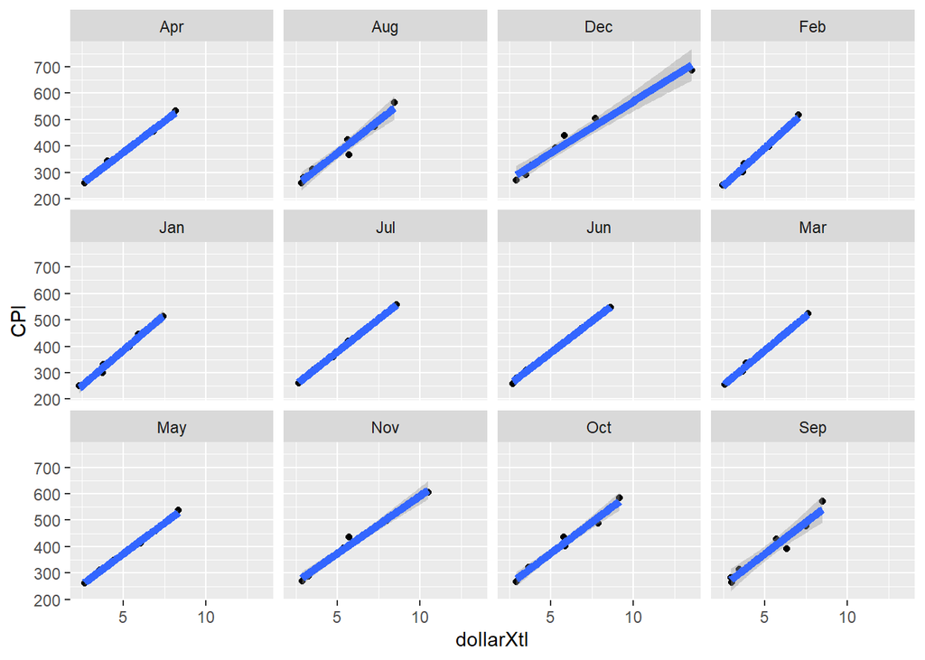

```r
ggplot(all_data_table,aes(x=dollarXtl,y=CPI)) +
        geom_point() + geom_smooth(method=lm,linewidth=2) + facet_wrap(~month)
```

AFC plot to see if the data correlates within itself.

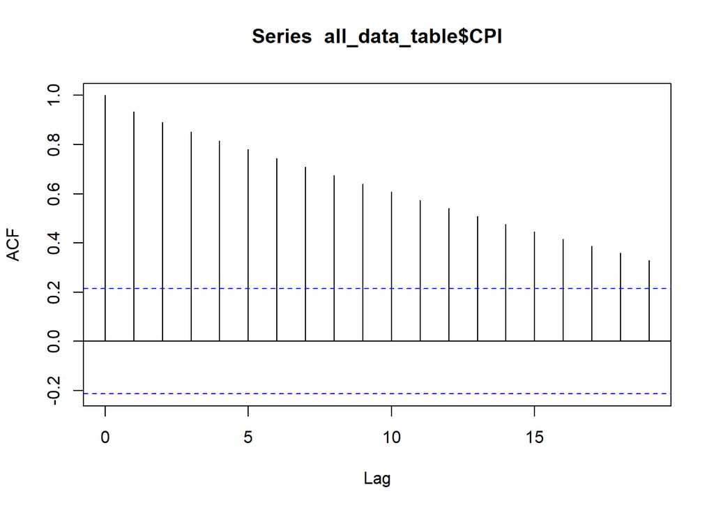

```r
acf(all_data_table$CPI)
```

First step is to start building the model. In this linear regression model, the Consumer Price Index (CPI) is analyzed using only the trend variable. The model shows a strong positive trend (coefficient = 4.1409, p-value < 2e-16), indicating a significant increase in CPI over time. The high R-squared value of 0.9423 suggests that the model explains approximately 94% of the variance in CPI, demonstrating a strong linear relationship between time and CPI in the dataset.

```r
model=lm(CPI~trnd,all_data_table)
summary(model)
```

```
##
## Call:
## lm(formula = CPI ~ trnd, data = all_data_table)
##
## Residuals:
##     Min      1Q  Median      3Q     Max
## -29.904 -13.865  -9.691  12.870 134.226
##
## Coefficients:
##             Estimate Std. Error t value Pr(>|t|)
## (Intercept) 204.8895     5.5349   37.02   <2e-16 ***
## trnd          4.1409     0.1131   36.61   <2e-16 ***
## ---
## Signif. codes:  0 '***' 0.001 '**' 0.01 '*' 0.05 '.' 0.1 ' ' 1
##
## Residual standard error: 25.14 on 82 degrees of freedom
## Multiple R-squared:  0.9423, Adjusted R-squared:  0.9416
## F-statistic:  1340 on 1 and 82 DF,  p-value: < 2.2e-16
```

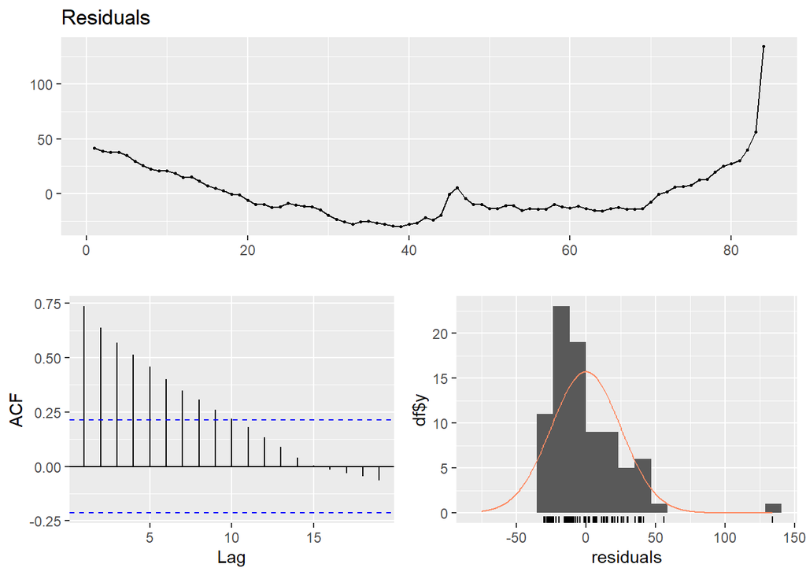

```
##
##  Ljung-Box test
##
## data:  Residuals
## Q* = 201.71, df = 10, p-value < 2.2e-16
##
## Model df: 0.   Total lags used: 10
```

```r
checkresiduals(model$residuals)
```

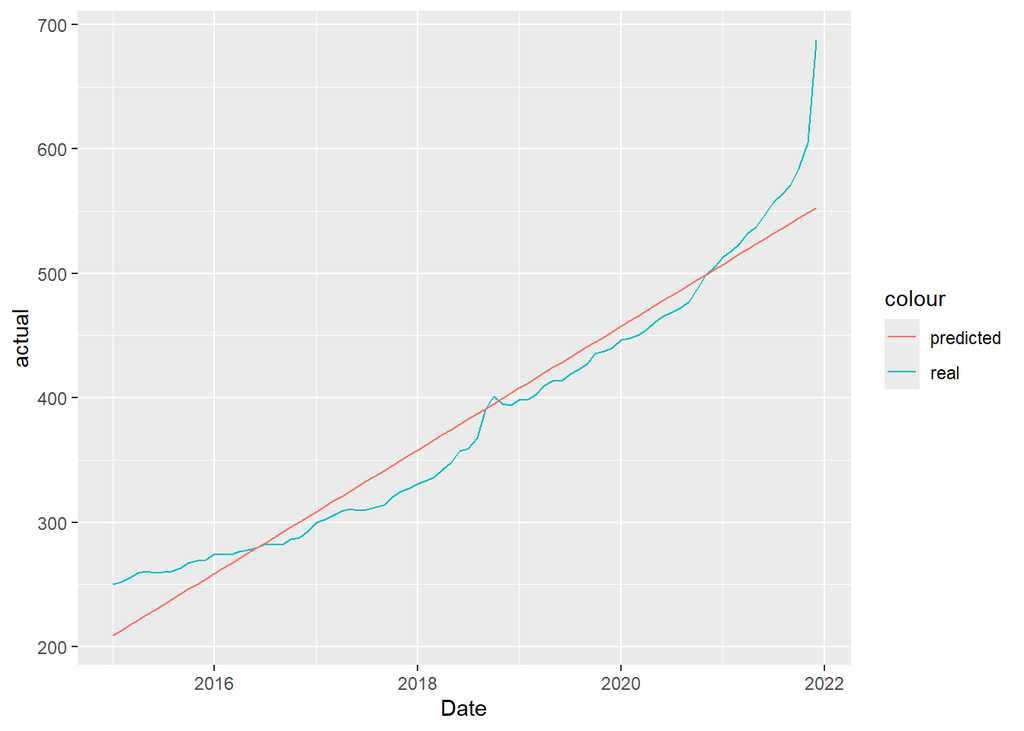

```r
tmp_data=copy(all_data_table)
tmp_data[,actual:=CPI]
tmp_data[,predicted_trend:=predict(model,tmp_data)]
tmp_data[,residual_trend:=actual-predicted_trend]
#head(tmp)
ggplot(tmp_data ,aes(x=Date)) +
        geom_line(aes(y=actual,color='real')) +
        geom_line(aes(y=predicted_trend,color='predicted'))
```

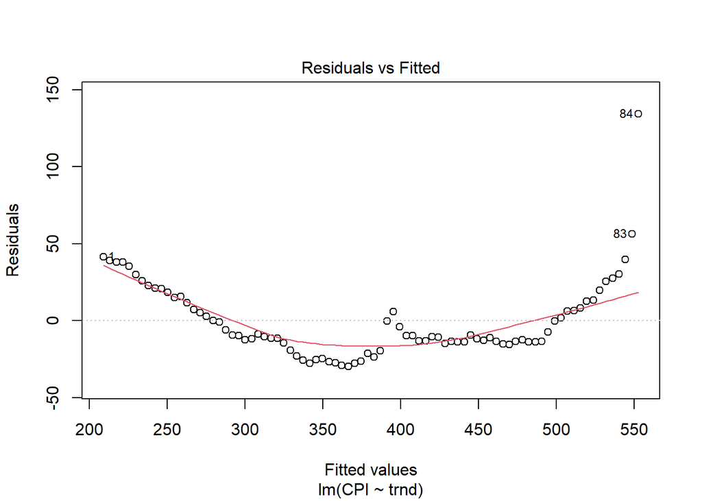

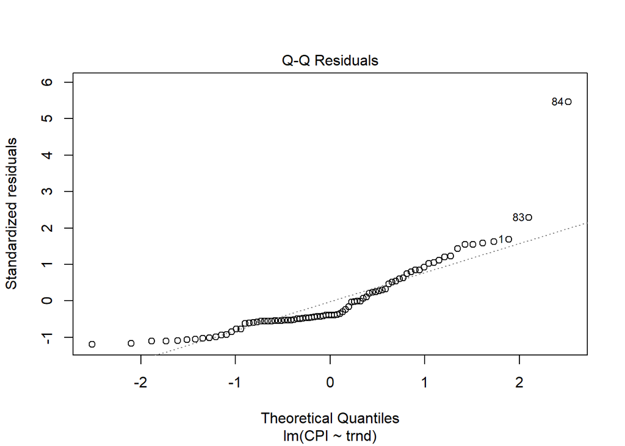

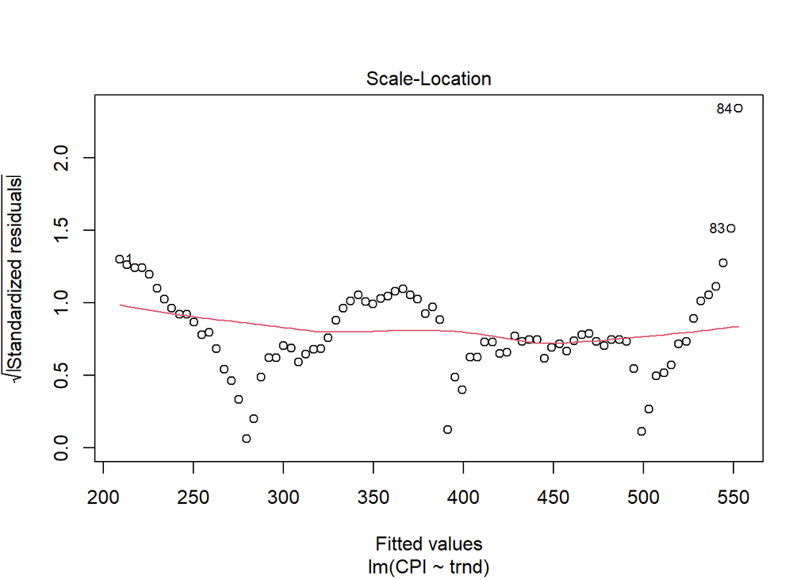

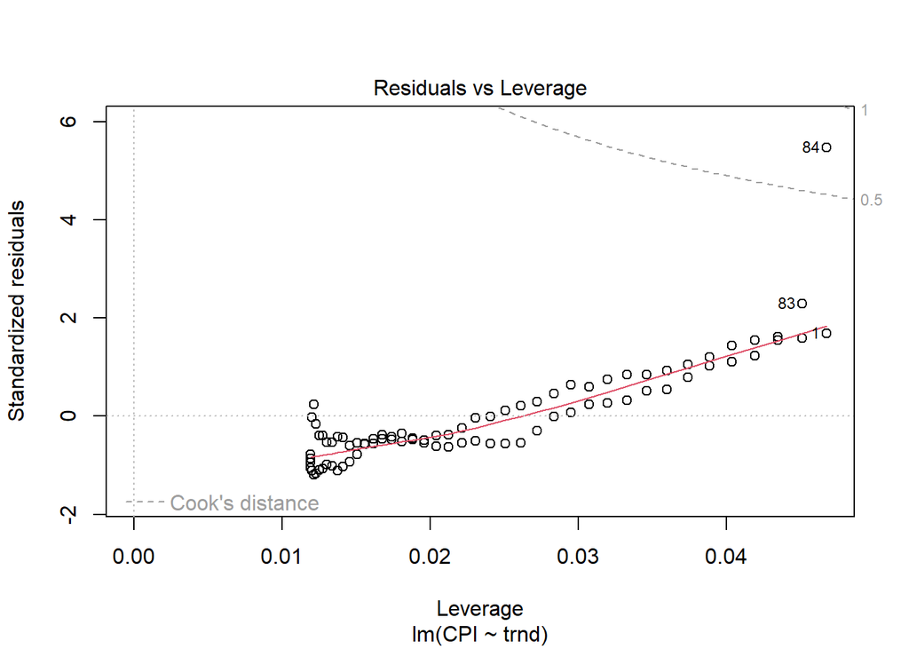

```r
plot(model)
```

For the next step we are adding dollar/tl exchange rate data-set into our model. In this regression analysis, the CPI is modeled using the trend and the exchange rate (dollar to Turkish lira). The model indicates a significant positive relationship with both the trend and the exchange rate, with notably high coefficients (trnd = 1.6725, dollarXtl = 28.9434, both with p-values < 2e-16). The model has an extremely high R-squared value of 0.9888, meaning it explains around 99% of the variance in CPI, showing a very strong linear relationship with these predictors.

```r
model=lm(CPI~trnd+dollarXtl,all_data_table)
summary(model)
```

```
##
## Call:
## lm(formula = CPI ~ trnd + dollarXtl, data = all_data_table)
##
## Residuals:
##     Min      1Q  Median      3Q     Max
## -33.905  -6.831  -0.877   5.638  27.375
##
## Coefficients:
##             Estimate Std. Error t value Pr(>|t|)
## (Intercept) 162.1254     3.3816   47.94   <2e-16 ***
## trnd          1.6725     0.1435   11.66   <2e-16 ***
## dollarXtl    28.9434     1.5766   18.36   <2e-16 ***
## ---
## Signif. codes:  0 '***' 0.001 '**' 0.01 '*' 0.05 '.' 0.1 ' ' 1
##
## Residual standard error: 11.13 on 81 degrees of freedom
## Multiple R-squared:  0.9888, Adjusted R-squared:  0.9886
## F-statistic:  3584 on 2 and 81 DF,  p-value: < 2.2e-16
```

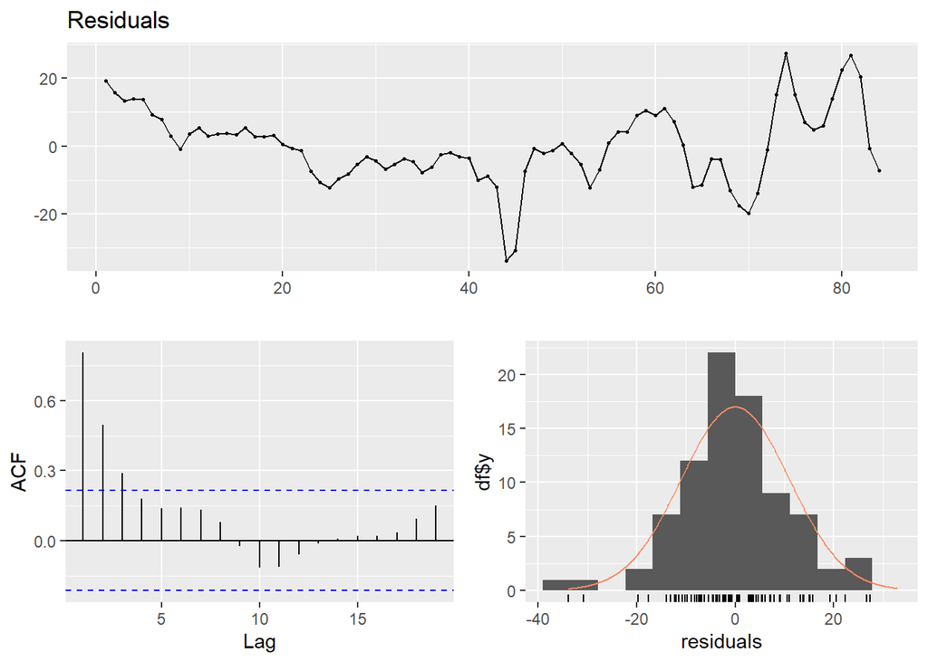

```
##
##  Breusch-Godfrey test for serial correlation of order up to 10
##
## data:  Residuals
## LM test = 63.678, df = 10, p-value = 7.25e-10
```

```r
checkresiduals(model)
```

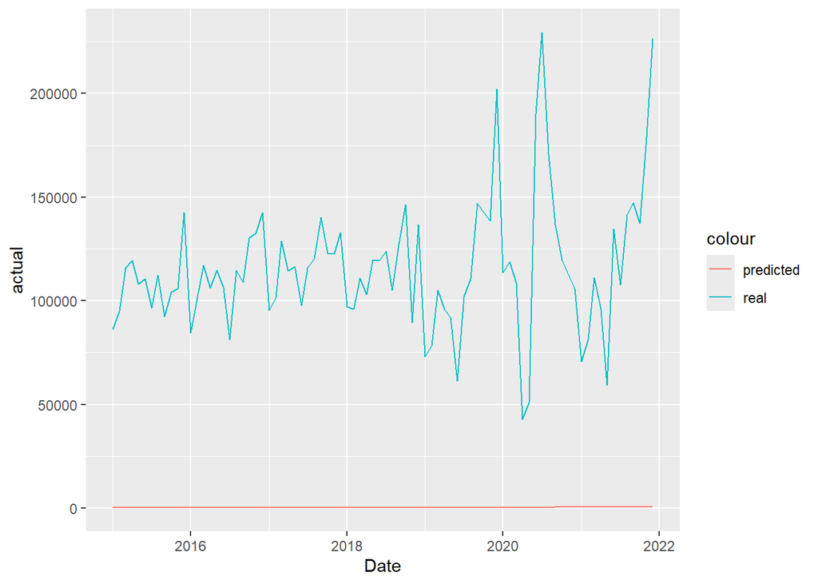

```r
tmp_data=copy(all_data_table)
tmp_data[,actual:=total_house_sales]
tmp_data[,predicted_trend_dollar:=predict(model,tmp_data)]
tmp_data[,residual_trend_dollar:=actual-predicted_trend_dollar]
ggplot(tmp_data ,aes(x=Date)) +
        geom_line(aes(y=actual,color='real')) +
        geom_line(aes(y=predicted_trend_dollar,color='predicted'))
```

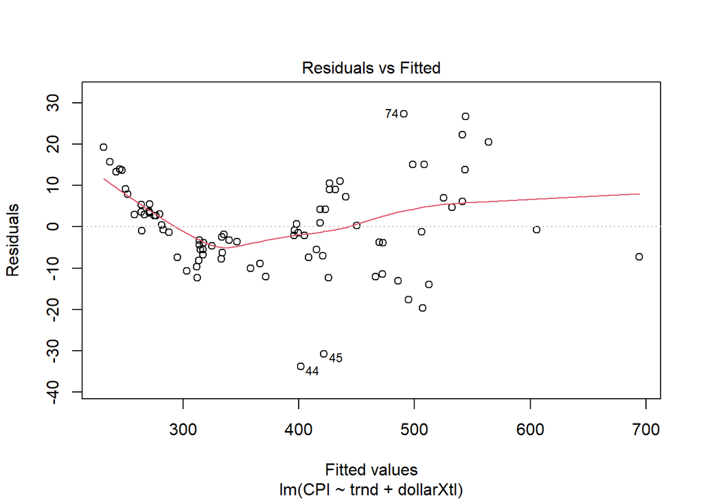

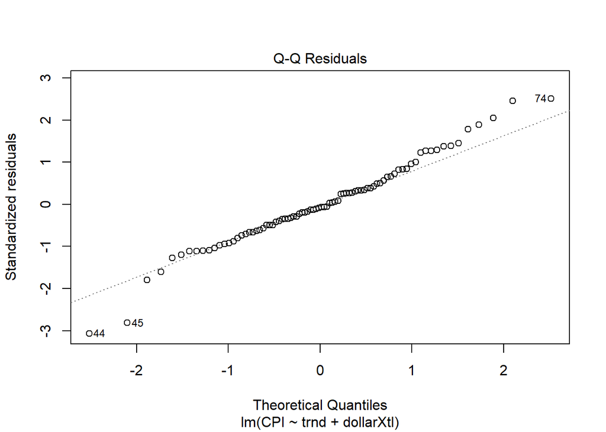

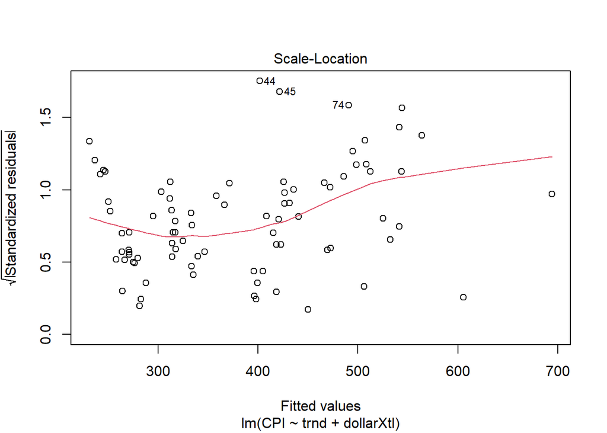

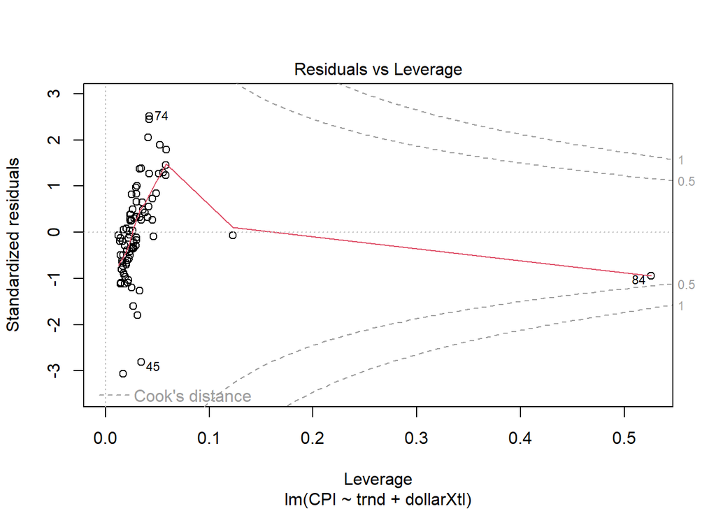

```r
plot(model)
```

For the next step I am adding year data to our model. In this model, CPI is predicted using the trend, the dollar to Turkish lira exchange rate, and the year. The results show significant positive effects for the trend and exchange rate on CPI. Yearly coefficients vary, with some years like 2016 and 2017 showing significant negative effects. The model has an extremely high R-squared value of 0.9966, indicating it accounts for nearly 100% of the variance in CPI, highlighting the strong influence of these factors on the CPI over time.

```r
model=lm((CPI)~trnd+(dollarXtl)+year,all_data_table)
summary(model)
```

```
##
## Call:
## lm(formula = (CPI) ~ trnd + (dollarXtl) + year, data = all_data_table)
##
## Residuals:
##      Min       1Q   Median       3Q      Max
## -18.2432  -4.0144   0.0815   3.7750  11.6248
##
## Coefficients:
##              Estimate Std. Error t value Pr(>|t|)
## (Intercept) 188.25568    3.13538  60.042  < 2e-16 ***
## trnd          1.93157    0.25326   7.627  6.1e-11 ***
## dollarXtl    21.98668    1.15471  19.041  < 2e-16 ***
## year2016     -9.51160    3.87042  -2.458   0.0163 *
## year2017    -15.16451    6.09939  -2.486   0.0151 *
## year2018    -13.32951    8.33189  -1.600   0.1138
## year2019      0.05671   10.80645   0.005   0.9958
## year2020     -1.14213   13.13069  -0.087   0.9309
## year2021     27.54986   15.34330   1.796   0.0766 .
## ---
## Signif. codes:  0 '***' 0.001 '**' 0.01 '*' 0.05 '.' 0.1 ' ' 1
##
## Residual standard error: 6.426 on 75 degrees of freedom
## Multiple R-squared:  0.9966, Adjusted R-squared:  0.9962
## F-statistic:  2711 on 8 and 75 DF,  p-value: < 2.2e-16
```

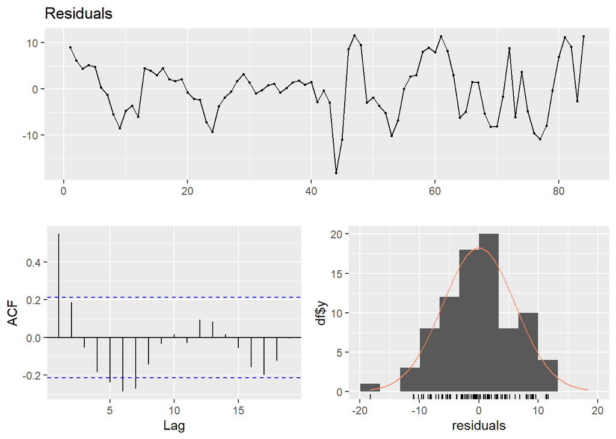

```
##
##  Breusch-Godfrey test for serial correlation of order up to 12
##
## data:  Residuals
## LM test = 43.399, df = 12, p-value = 1.932e-05
```

```r
checkresiduals(model)
```

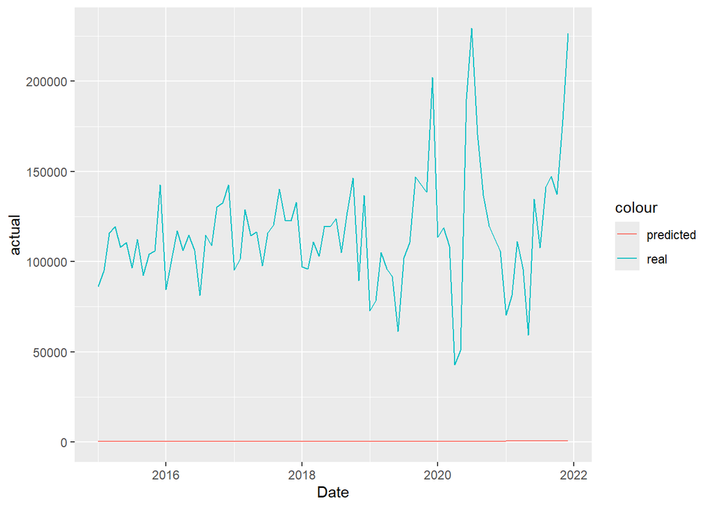

```r
tmp_data=copy(all_data_table)
tmp_data[,actual:=total_house_sales]
tmp_data[,predicted_trend_dollar_year:=predict(model,tmp_data)]
tmp_data[,residual_trend_dollar_year:=actual-predicted_trend_dollar_year]
ggplot(tmp_data ,aes(x=Date)) +
        geom_line(aes(y=actual,color='real')) +
        geom_line(aes(y=predicted_trend_dollar_year,color='predicted'))
```

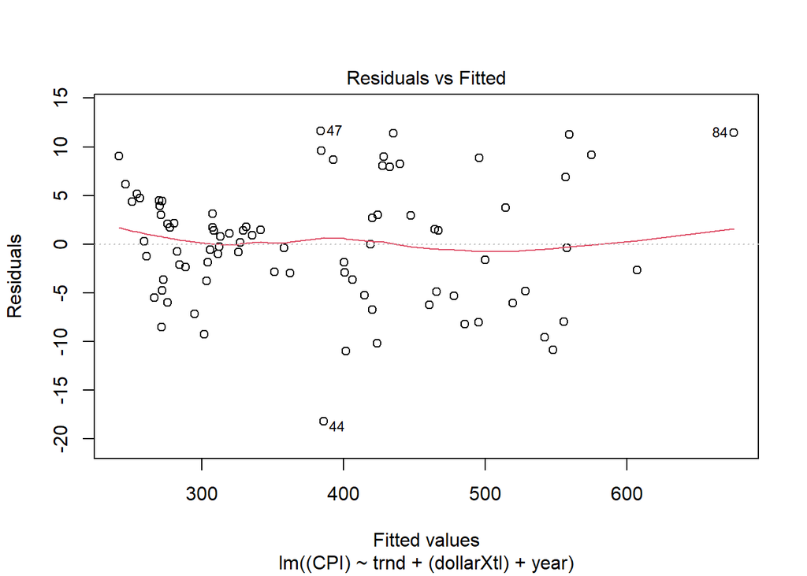

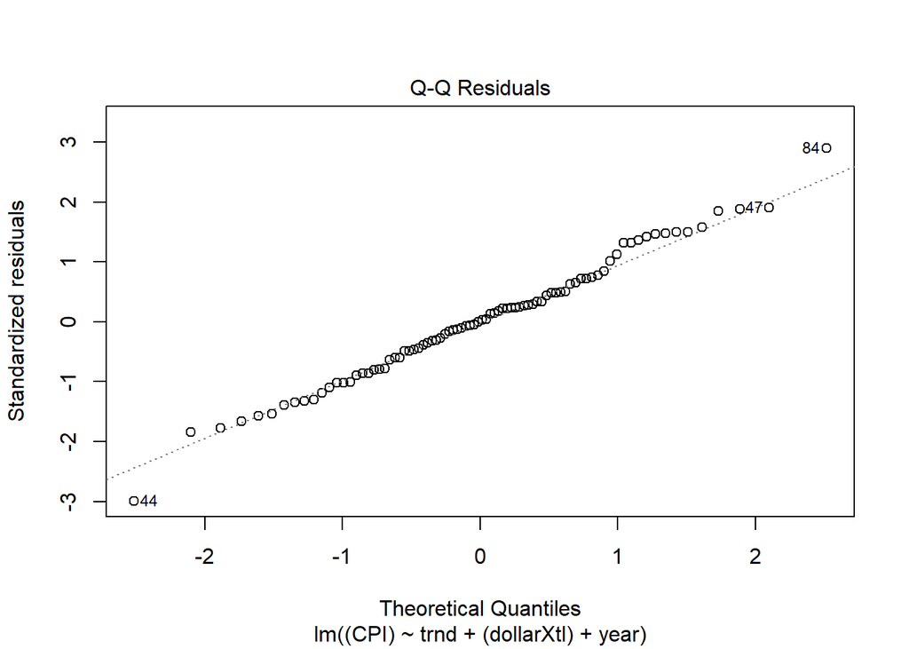

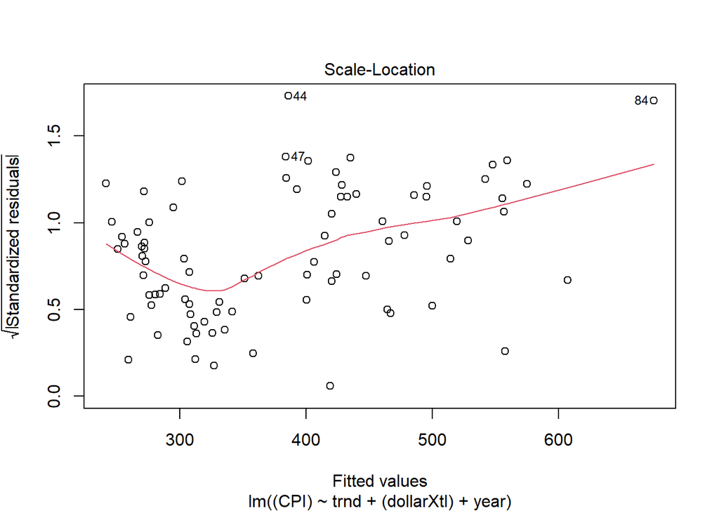

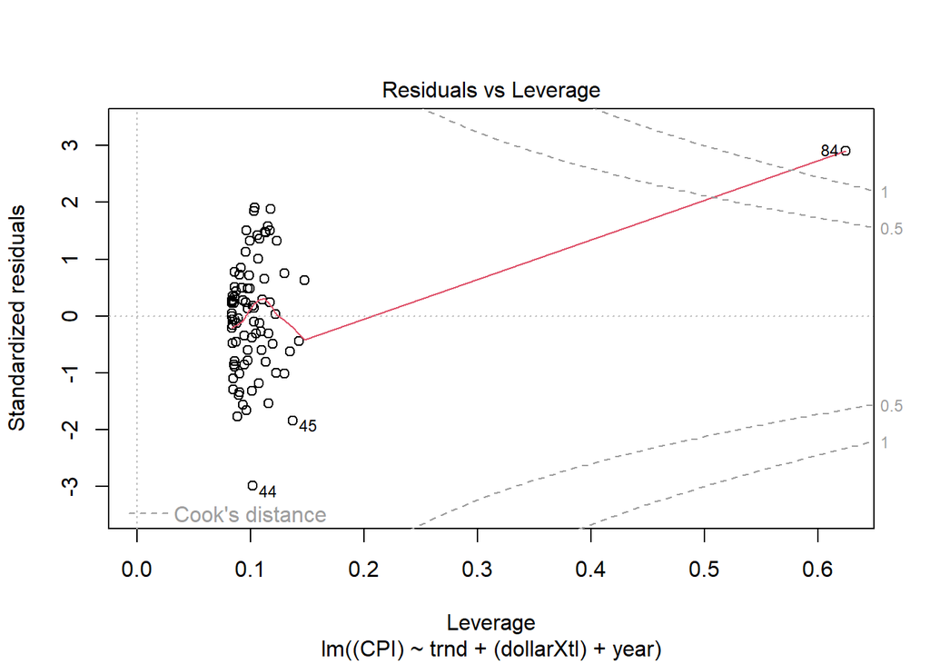

```r
plot(model)
```

# MODEL 3 (Unemployment Rate)

For the final model, I aimed to forecast the unemployment rate, with the following graph depicting the temporal trend of unemployment in Turkey.

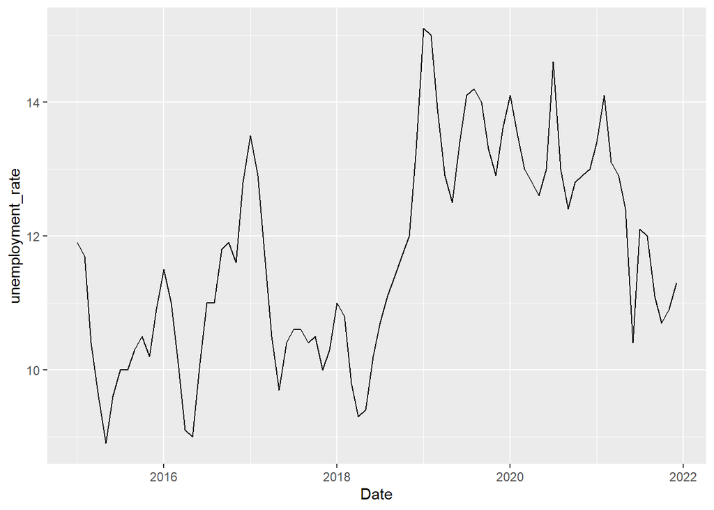

```r
ggplot(all_data_table ,aes(x=Date,y=unemployment_rate, group=1)) + geom_line()
```

I concluded that the volume of job-related searches on Google could be a reliable predictor for the unemployment rate. Below is a scatter plot with a regression line that illustrates the relationship between the unemployment rate and the frequency of Google job searches.

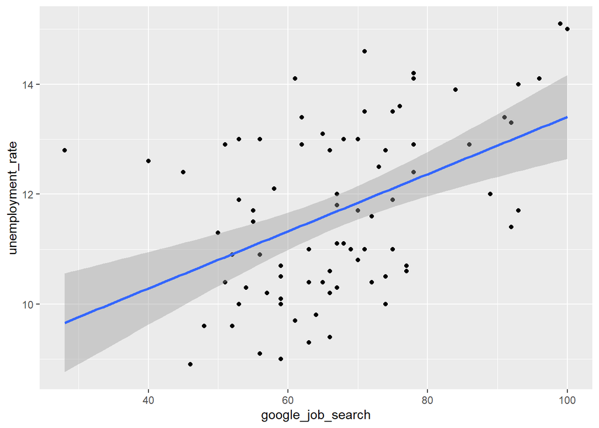

```r
ggplot(all_data_table ,aes(x=google_job_search,y=unemployment_rate)) + geom_point() +geom_smooth(method='lm')
```

The graphs below shows the correlation between number of searches in google and unemployment rate for each month.

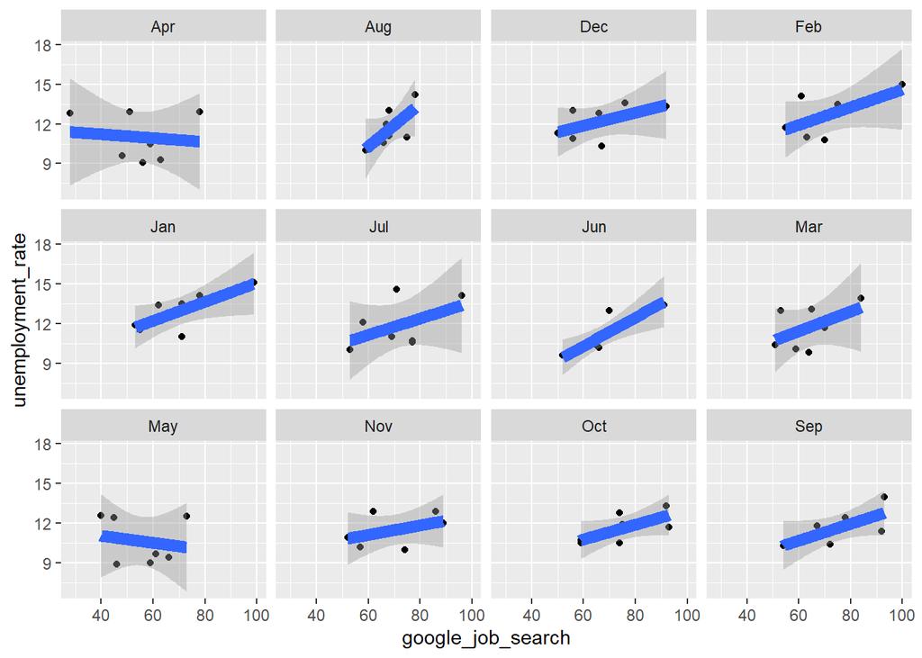

```r
ggplot(all_data_table,aes(x=google_job_search,y=unemployment_rate)) +
        geom_point() + geom_smooth(method=lm,linewidth=3) + facet_wrap(~month)
```

ACF to see whether there is a correlation within the data itself.

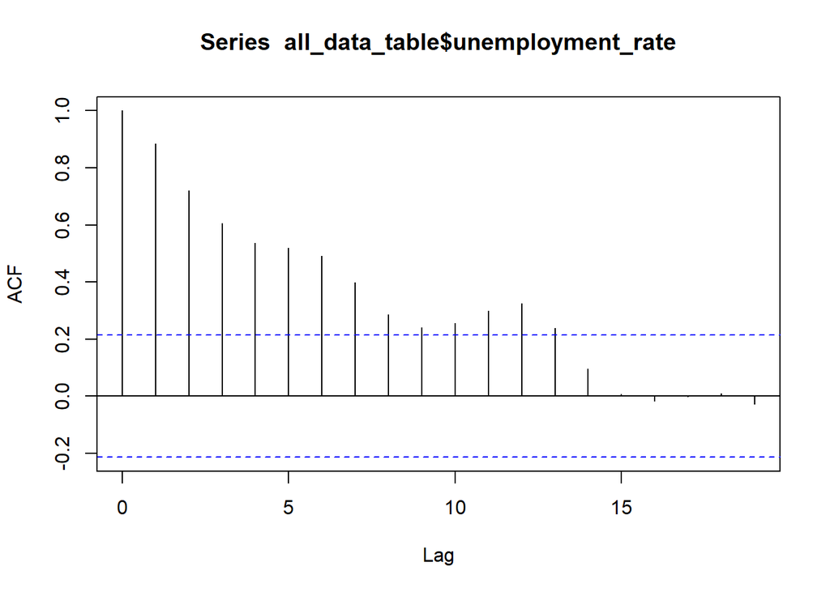

```r
acf(all_data_table$unemployment_rate)
```

```r
model=lm(unemployment_rate~trnd,all_data_table)
summary(model)
```

```
##
## Call:
## lm(formula = unemployment_rate ~ trnd, data = all_data_table)
##
## Residuals:
##      Min       1Q   Median       3Q      Max
## -2.56046 -0.83699  0.08061  0.84834  3.16046
##
## Coefficients:
##              Estimate Std. Error t value Pr(>|t|)
## (Intercept) 10.214544   0.286521  35.650  < 2e-16 ***
## trnd         0.035204   0.005856   6.012 4.87e-08 ***
## ---
## Signif. codes:  0 '***' 0.001 '**' 0.01 '*' 0.05 '.' 0.1 ' ' 1
##
## Residual standard error: 1.301 on 82 degrees of freedom
## Multiple R-squared:  0.3059, Adjusted R-squared:  0.2975
## F-statistic: 36.14 on 1 and 82 DF,  p-value: 4.869e-08
```

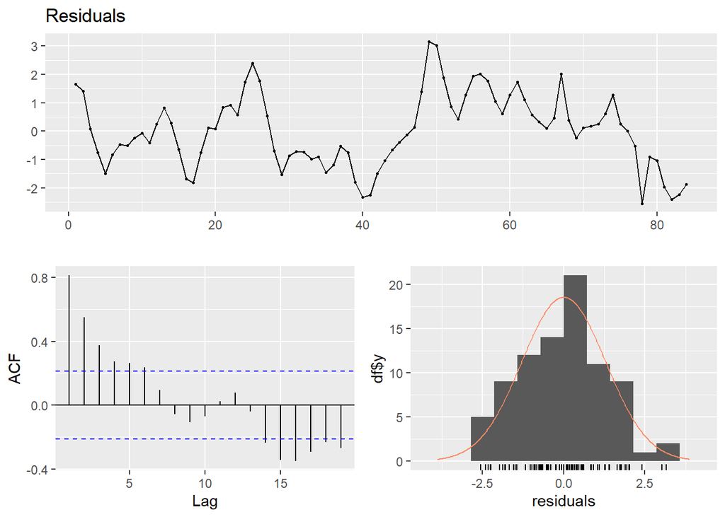

```
##
##  Ljung-Box test
##
## data:  Residuals
## Q* = 117.48, df = 10, p-value < 2.2e-16
##
## Model df: 0.   Total lags used: 10
```

```r
checkresiduals(model$residuals)
```

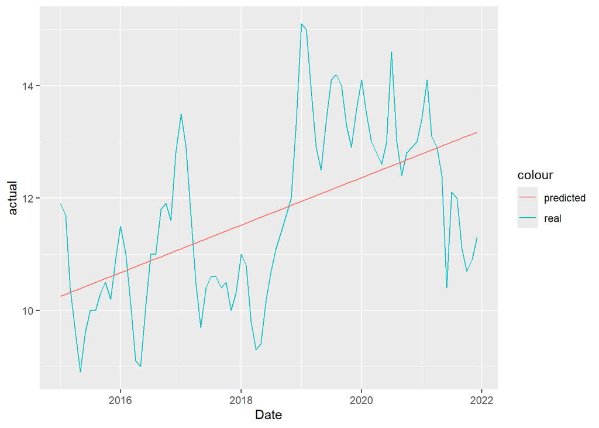

```r
tmp_data=copy(all_data_table)
tmp_data[,actual:=unemployment_rate]
tmp_data[,predicted_trend:=predict(model,tmp_data)]
tmp_data[,residual_trend:=actual-predicted_trend]
#head(tmp)
ggplot(tmp_data ,aes(x=Date)) +
        geom_line(aes(y=actual,color='real')) +
        geom_line(aes(y=predicted_trend,color='predicted'))
```

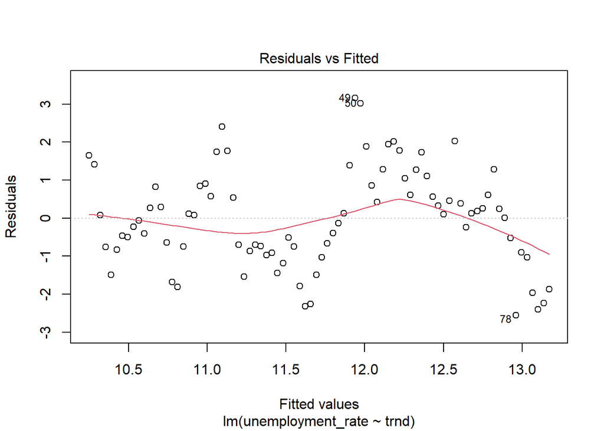

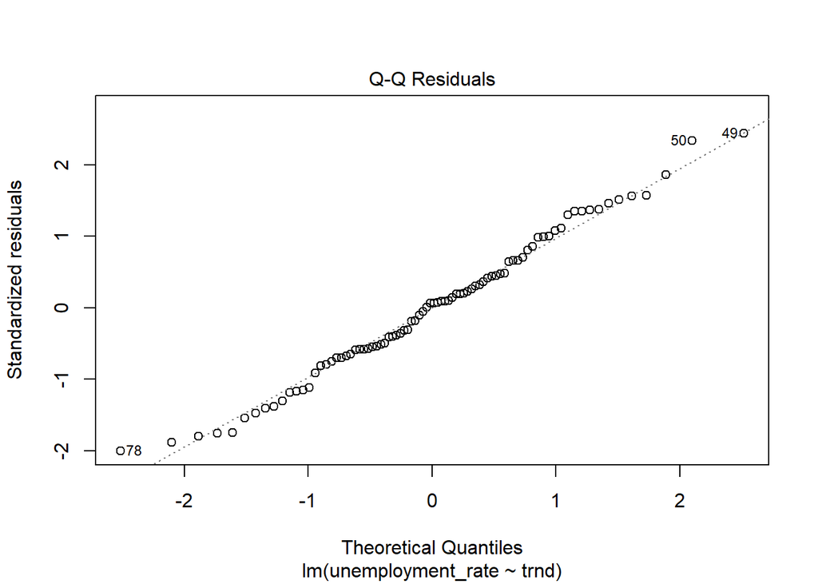

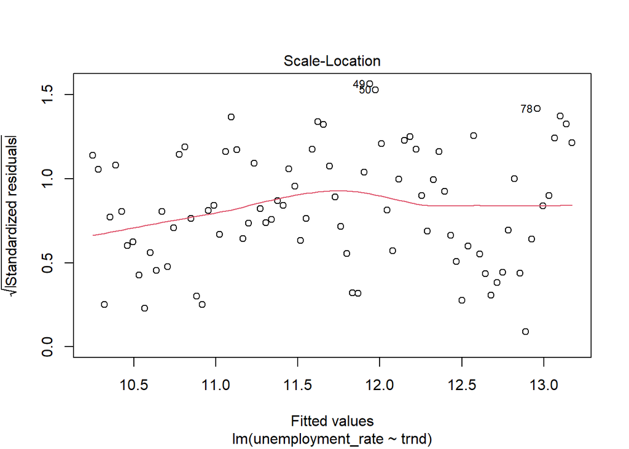

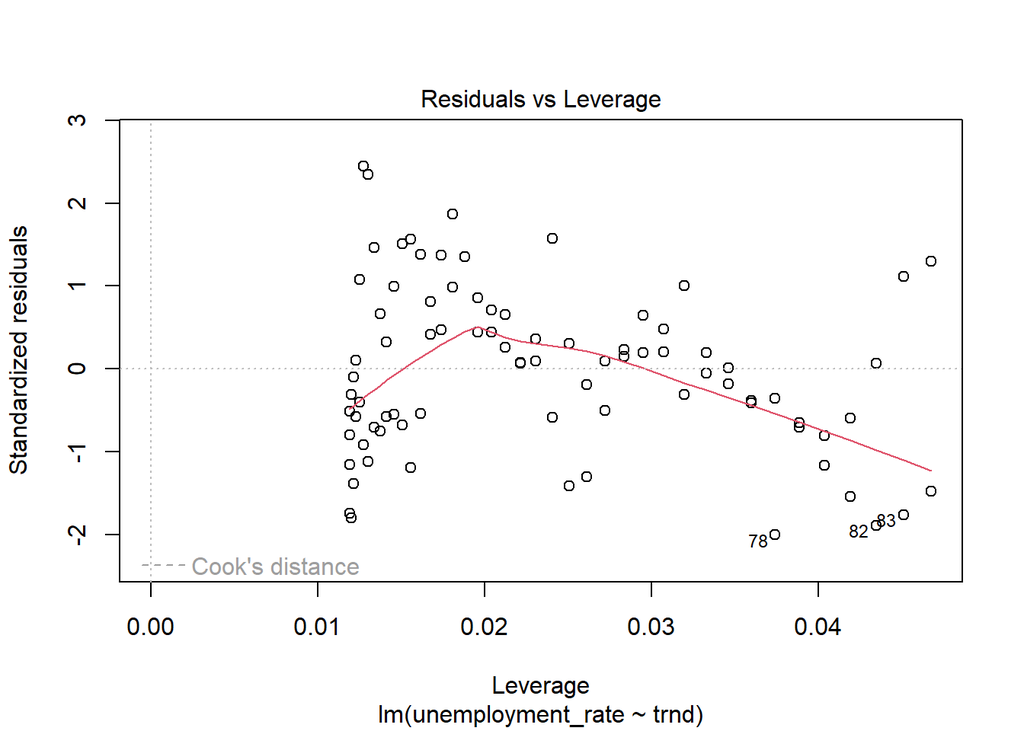

```r
plot(model)
```

```r
model=lm((unemployment_rate)~trnd+(google_job_search),all_data_table)
summary(model)
```

```
##
## Call:
## lm(formula = (unemployment_rate) ~ trnd + (google_job_search),
##     data = all_data_table)
##
## Residuals:
##      Min       1Q   Median       3Q      Max
## -2.22617 -0.86622  0.03106  0.79539  2.17921
##
## Coefficients:
##                   Estimate Std. Error t value Pr(>|t|)
## (Intercept)       7.482880   0.638877  11.713  < 2e-16 ***
## trnd              0.031134   0.005303   5.871 9.13e-08 ***
## google_job_search 0.043092   0.009234   4.667 1.20e-05 ***
## ---
## Signif. codes:  0 '***' 0.001 '**' 0.01 '*' 0.05 '.' 0.1 ' ' 1
##
## Residual standard error: 1.162 on 81 degrees of freedom
## Multiple R-squared:  0.453,  Adjusted R-squared:  0.4395
## F-statistic: 33.54 on 2 and 81 DF,  p-value: 2.448e-11
```

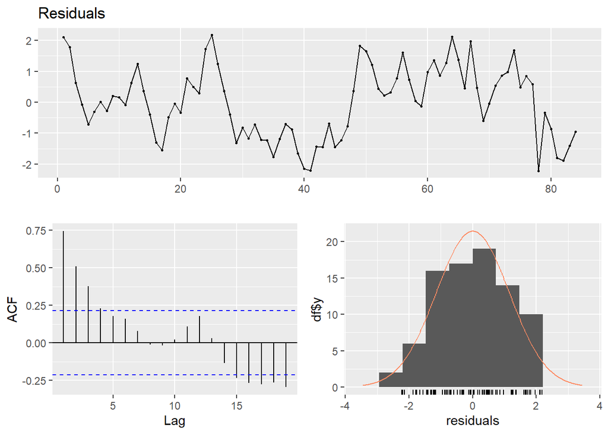

```
##
##  Breusch-Godfrey test for serial correlation of order up to 10
##
## data:  Residuals
## LM test = 50.463, df = 10, p-value = 2.193e-07
```

```r
checkresiduals(model)
```

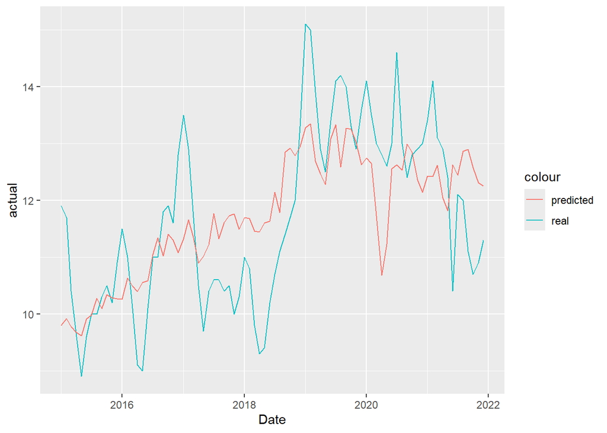

```r
tmp_data = copy(all_data_table)
tmp_data[,actual:=unemployment_rate]
tmp_data[,predicted_trend_job_search_year:=predict(model,tmp_data)]
tmp_data[,residual_trend_job_search_year:=actual-predicted_trend_job_search_year]
ggplot(tmp_data ,aes(x=Date)) +
        geom_line(aes(y=actual,color='real')) +
        geom_line(aes(y=predicted_trend_job_search_year,color='predicted'))
```

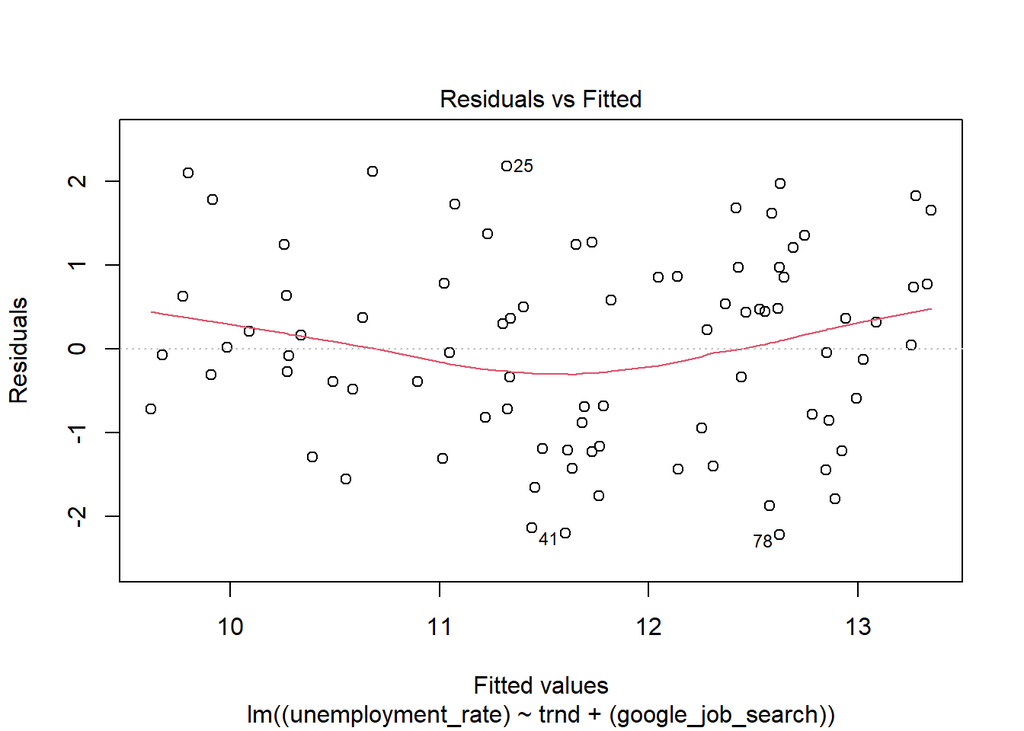

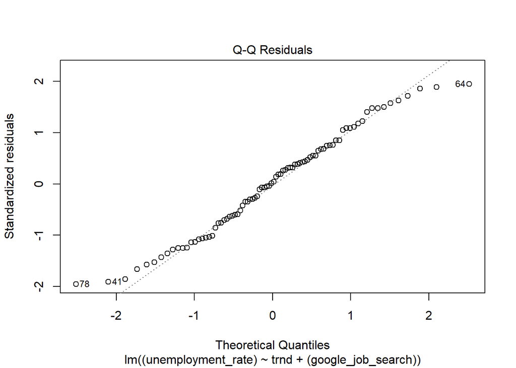

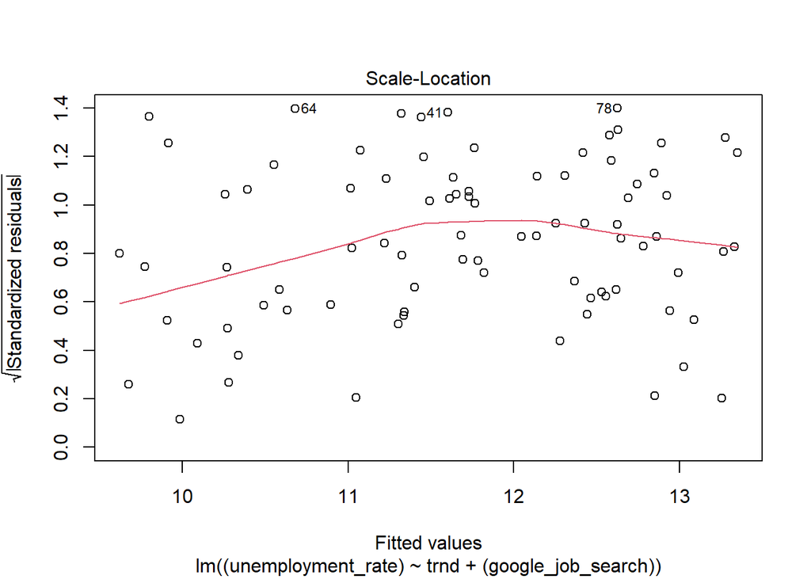

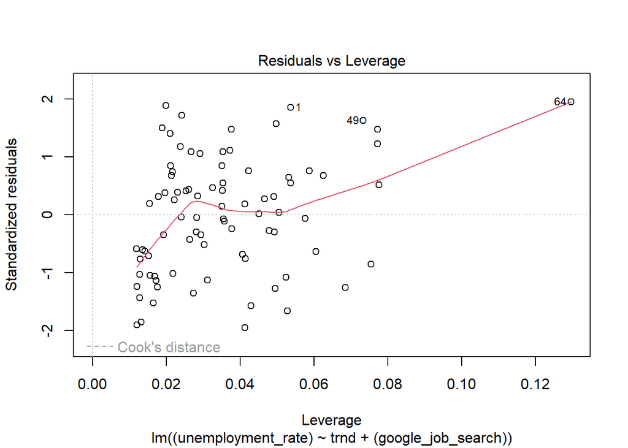

```r
plot(model)
```

For the last step we are adding years to our model. This model predicts the unemployment rate using trend, Google job search data, and year. The negative trend coefficient suggests a slight decrease over time in the unemployment rate, but Google job searches positively correlate with unemployment, indicating that more searches are associated with higher unemployment rates. Yearly effects are significant, especially in later years, showing increasing unemployment rates. The model’s R-squared value of 0.7102 means it explains 71% of the variance in unemployment, demonstrating a strong fit with the data.

```r
model=lm(unemployment_rate~trnd+google_job_search+year,all_data_table)
summary(model)
```

```
##
## Call:
## lm(formula = unemployment_rate ~ trnd + google_job_search + year,
##     data = all_data_table)
##
## Residuals:
##      Min       1Q   Median       3Q      Max
## -1.91905 -0.55374 -0.07277  0.63695  2.23559
##
## Coefficients:
##                   Estimate Std. Error t value Pr(>|t|)
## (Intercept)        7.98540    0.61872  12.906  < 2e-16 ***
## trnd              -0.07620    0.02852  -2.672 0.009245 **
## google_job_search  0.05306    0.01075   4.935 4.71e-06 ***
## year2016           0.90570    0.49169   1.842 0.069427 .
## year2017           1.57587    0.75761   2.080 0.040937 *
## year2018           2.11644    1.06291   1.991 0.050105 .
## year2019           5.28388    1.38240   3.822 0.000271 ***
## year2020           6.89385    1.72932   3.986 0.000154 ***
## year2021           6.93426    2.07371   3.344 0.001292 **
## ---
## Signif. codes:  0 '***' 0.001 '**' 0.01 '*' 0.05 '.' 0.1 ' ' 1
##
## Residual standard error: 0.8792 on 75 degrees of freedom
## Multiple R-squared:  0.7102, Adjusted R-squared:  0.6793
## F-statistic: 22.97 on 8 and 75 DF,  p-value: < 2.2e-16
```

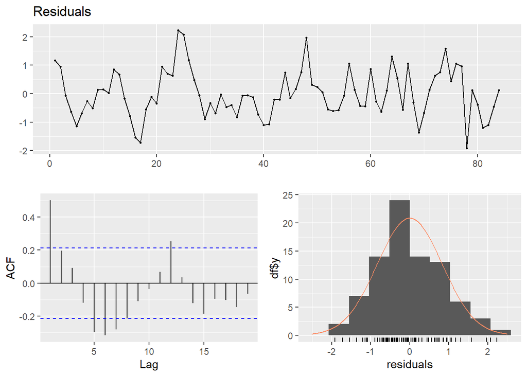

```
##
##  Ljung-Box test
##
## data:  Residuals
## Q* = 58.014, df = 10, p-value = 8.591e-09
##
## Model df: 0.   Total lags used: 10
```

```r
checkresiduals(model$residuals)
```

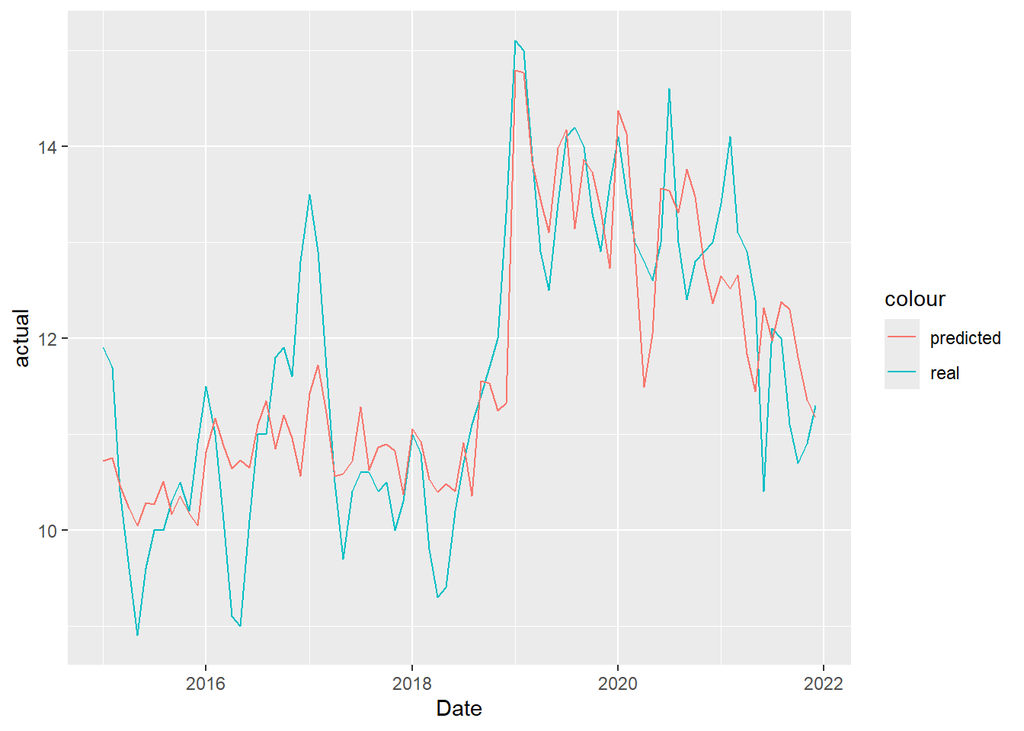

```r
tmp_data=copy(all_data_table)
tmp_data[,actual:=unemployment_rate]
tmp_data[,predicted_trend_unemployment_rate_job_search_year:=predict(model,tmp_data)]
tmp_data[,residual_trend_unemployment_rate_job_search_year:=actual-predicted_trend_unemployment_rate_job_search_year]
#head(tmp)
ggplot(tmp_data ,aes(x=Date)) +
        geom_line(aes(y=actual,color='real')) +
        geom_line(aes(y=predicted_trend_unemployment_rate_job_search_year,color='predicted'))
```

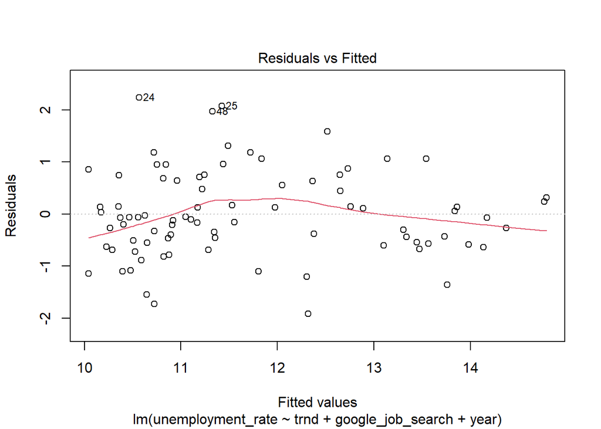

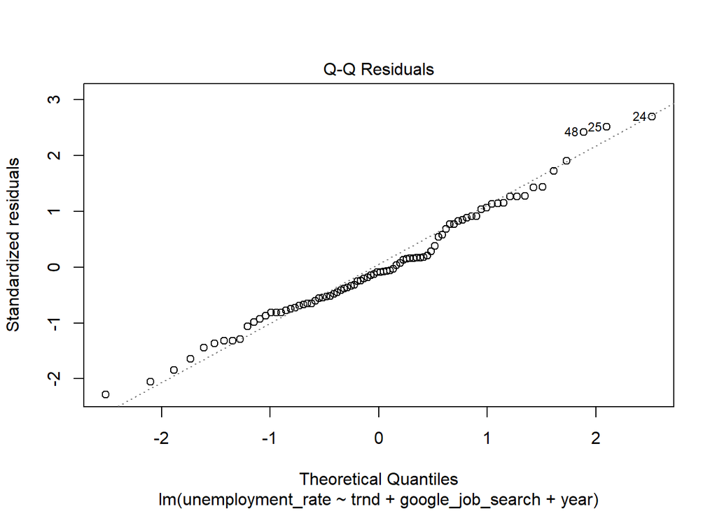

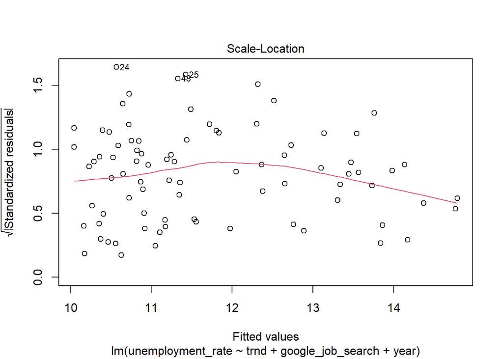

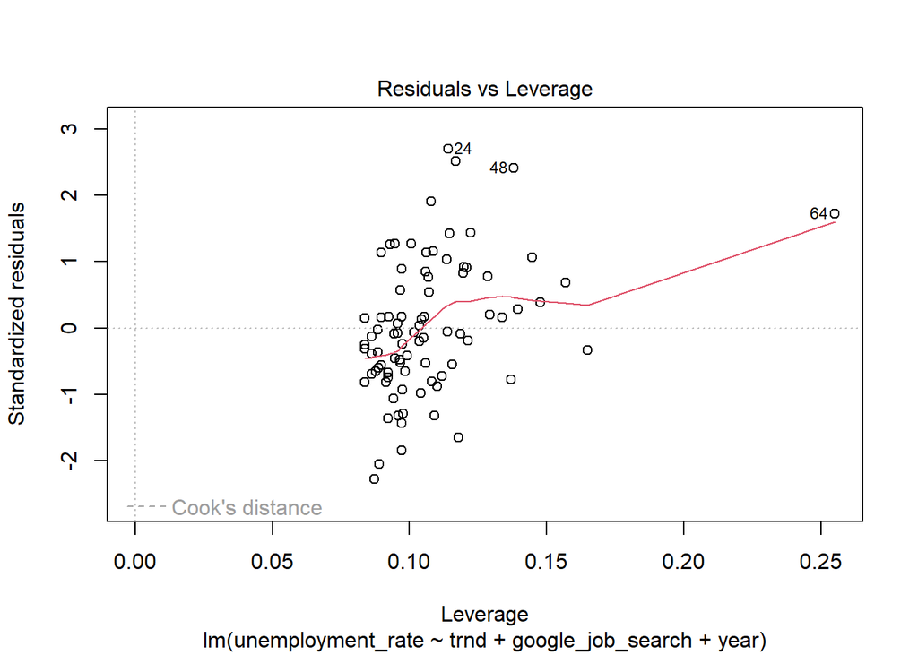

```r
plot(model)
```

# Conclusion

In the first model, focusing on total house sales in Turkey, we found a slight upward trend, suggesting a gradual increase in sales over time. However, the model’s accuracy, as indicated by an R-squared value of around 0.05, was relatively low, pointing to other influential factors not captured in the analysis. The residuals, with a wide range, hinted at significant variability unexplained by the model. Autocorrelation was also evident, suggesting that past sales figures have some influence on future ones, a detail not fully accounted for in the model.

The second analysis delved into the Consumer Price Index (CPI) and demonstrated a substantial improvement in modeling accuracy, with an R-squared value close to 0.99. This high R-squared value indicated that the model, which included the trend and exchange rate variables, could account for most of the variability in the CPI. The residuals were considerably smaller, implying a better fit of the model to the data. The precise estimation of CPI changes highlighted the strong impact of the included variables, although the exact autocorrelation values were not specified, the close fit suggests that the model captured the underlying pattern effectively.

The third model aimed to predict the unemployment rate, incorporating variables such as trend, Google job search data, and annual changes. This model achieved an R-squared value of about 0.71, indicating a good level of fit and a substantial improvement over the first model. It managed to capture significant year-to-year fluctuations and showed that Google search trends for jobs had a notable effect on the unemployment rate. The model’s residuals were smaller and more consistent than in the first model, indicating less unexplained variance. However, like the other models, it exhibited some degree of autocorrelation, suggesting that incorporating additional lagged variables or adjusting the model could potentially improve its predictive power.